# Pinguins

**Note**: this This exercise is based on the vignette “[PCA with penguins and recipes](https://allisonhorst.github.io/palmerpenguins/articles/pca.html)” developed by Allison Horst, Alison Hill, Kristen Gorman.

# 1. Installation

```r
install.packages("palmerpenguins")
install.packages("embed")
```

# 2. Create a report

```r
library(palmerpenguins)
DataExplorer::create_report(penguins, output_file = "report_pinguins.html")
```

- `create_report()` function from the {DataExplorer} package generates an exploratory data analysis (EDA) report for the penguins dataset.
- The dataset `penguins` contains information about three species of penguins that inhabit the Palmer Archipelago, near the Antarctic Peninsula.

# 3. PCA with penguins and recipes

You’ll need these packages to follow along with the code in this article locally:

```r
library(palmerpenguins)
library(corrr)
library(GGally)
library(recipes)
library(tidytext)
library(dplyr)
library(tidyr)
library(ggplot2)
theme_set(theme_minimal())
```

## 3.1 Correlation Matrix

The `palmerpenguins::penguins` data contains several size measurement variables that are correlated. Let’s take a look at the correlation matrix with the {corrr} package and the `corrr::correlate()` function:

```r
# Load the corrr library
library(corrr)
# Select specific columns from the "penguins" dataset and compute the correlation matrix
penguins_corr <- penguins %>%
  dplyr::select(body_mass_g, ends_with("_mm")) %>%
  correlate() %>%
  rearrange()
# Display the resulting correlation matrix
penguins_corr
```

```
## # A tibble: 4 × 5
##   term              flipper_length_mm body_mass_g bill_length_mm bill_depth_mm
##   <chr>                         <dbl>       <dbl>          <dbl>         <dbl>
## 1 flipper_length_mm            NA           0.871          0.656        -0.584
## 2 body_mass_g                   0.871      NA              0.595        -0.472
## 3 bill_length_mm                0.656       0.595         NA            -0.235
## 4 bill_depth_mm                -0.584      -0.472         -0.235        NA
```

- {corrr} package provides tools for working with correlation matrices.
- `dplyr::select` function is used to choose specific columns from the “`penguins`” dataset. In this case, it selects the “`body_mass_g`” column and all columns that end with “`_mm`”.
- `%>%` operator (pipe) is used to pass the selected columns to the next function, `correlate()`. This function calculates the correlation matrix for the selected columns.
- `rearrange()` function rearranges the correlation matrix to group highly correlated variables together, making it easier to identify patterns.

**Body mass and flipper length appear highly correlated**, but neither of the bill variables appears to be as highly correlated with any other variables.

## 3.2 Pairwise plot matrix

We can visualize these correlations with the {GGally} package. The function we’ll use is called `GGally::ggpairs()`.

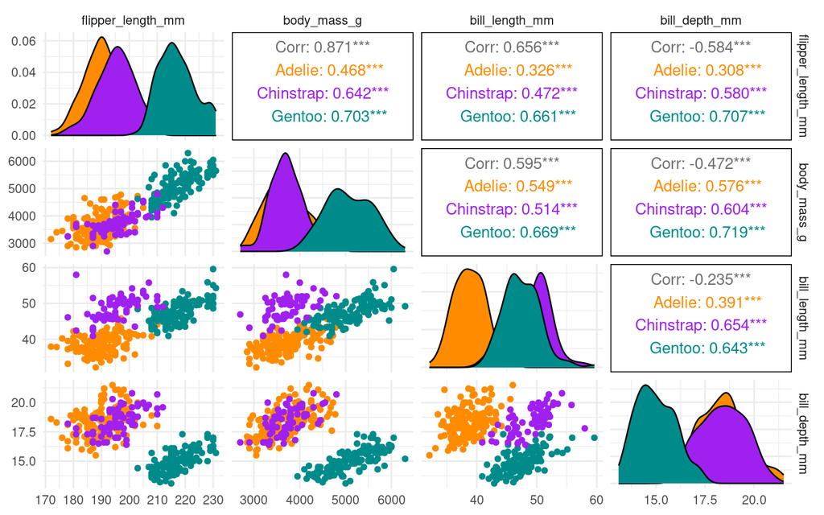

```r
penguins %>%
  # Subset the dataset
  select(species, body_mass_g, ends_with("_mm")) %>%
  # Create a scatterplot matrix
  GGally::ggpairs(aes(color = species),
          columns = c("flipper_length_mm", "body_mass_g",
                      "bill_length_mm", "bill_depth_mm")) +
  # Customize colors
  scale_colour_manual(values = c("darkorange","purple","cyan4")) +
  scale_fill_manual(values = c("darkorange","purple","cyan4"))
```

- `select(species, body_mass_g, ends_with("_mm"))` is used to select columns “`species`”, “`body_mass_g`,” and any columns ending with “`_mm`” from the “`penguins`” dataset.
- `aes(color = species)` specifies that the points in the scatterplot matrix should be colored based on the “`species`” variable.

## 3.3 Principal component analysis (PCA)

We’ll use the recipes package from tidymodels to perform a principal component analysis (PCA).

First, we’ll also use a few recipe steps to preprocess the data for PCA; namely, we need to:

- remove any `NA` values,
- center all predictors, and
- scale all predictors.

```r
# Load the recipes library
library(recipes)
# Create a recipe for preprocessing and PCA transformation
penguin_recipe <-
  recipe(~., data = penguins) %>%  # Create a recipe
  update_role(species, island, sex, year, new_role = "id") %>%  # Update roles
  step_naomit(all_predictors()) %>%  # Handle missing values
  step_normalize(all_predictors()) %>%  # Normalize predictors
  step_pca(all_predictors(), id = "pca") %>%  # Apply PCA
  prep()  # Prepare the recipe
# Apply the recipe and extract the PCA results
penguin_pca <-
  penguin_recipe %>%
  tidy(id = "pca")
# Display the PCA results
penguin_pca
```

```
## # A tibble: 16 × 4
##    terms                value component id
##    <chr>                <dbl> <chr>     <chr>
##  1 bill_length_mm     0.455   PC1       pca
##  2 bill_depth_mm     -0.400   PC1       pca
##  3 flipper_length_mm  0.576   PC1       pca
##  4 body_mass_g        0.548   PC1       pca
##  5 bill_length_mm    -0.597   PC2       pca
##  6 bill_depth_mm     -0.798   PC2       pca
##  7 flipper_length_mm -0.00228 PC2       pca
##  8 body_mass_g       -0.0844  PC2       pca
##  9 bill_length_mm    -0.644   PC3       pca
## 10 bill_depth_mm      0.418   PC3       pca
## 11 flipper_length_mm  0.232   PC3       pca
## 12 body_mass_g        0.597   PC3       pca
## 13 bill_length_mm     0.146   PC4       pca
## 14 bill_depth_mm     -0.168   PC4       pca
## 15 flipper_length_mm -0.784   PC4       pca
## 16 body_mass_g        0.580   PC4       pca
```

- `recipe` function is used to define a recipe for preprocessing and transformation. The formula `~.` specifies that all columns in the “`penguins`” dataset should be included in the recipe.
- `update_role` function is used to update the roles of specific variables. The roles of “`species`,” “`island`,” “`sex`,” and “`year`” are updated to a new role called “`id`.” This typically indicates that these variables are identifiers and should not be used as predictors in modeling.
- `step_naomit` function is applied to remove rows with missing values in any predictor variable.
- `step_normalize` function is applied to normalize (standardize) all predictor variables.
- `step_pca` function is applied to perform Principal Component Analysis (PCA) on all predictor variables. The resulting principal components are assigned the identifier “`pca`.”
- `prep` function is used to prepare the recipe, applying the specified preprocessing steps to the “`penguins`” dataset.
- `tidy` function is used to extract information about the PCA results from the prepared recipe. The argument `id = "pca"` indicates that we want information specific to the PCA step.

The `value` column here is the loading. For each component, the value tells us the linear combination of weights for each variable that contributes to that component.

This output is a tidy version of this using `stats::prcomp()`:

```r
penguins %>%
  dplyr::select(body_mass_g, ends_with("_mm")) %>%  # Remove rows with missing values
  tidyr::drop_na() %>%
  scale() %>%  # scale the data
  prcomp() %>%  # perform PCA
  .$rotation  # Extract the rotation matrix
```

```
##                          PC1         PC2        PC3        PC4
## body_mass_g        0.5483502 0.084362920  0.5966001  0.5798821
## bill_length_mm     0.4552503 0.597031143 -0.6443012  0.1455231
## bill_depth_mm     -0.4003347 0.797766572  0.4184272 -0.1679860
## flipper_length_mm  0.5760133 0.002282201  0.2320840 -0.7837987
```

- `tidyr::drop_na()` is used to remove rows with missing values in the selected columns.
- `scale()` is applied to standardize the selected variables by subtracting the mean and dividing by the standard deviation. This step is crucial for PCA, as it ensures that variables with different units or scales are comparable.
- `prcomp()` is used to perform principal component analysis on the scaled data. This function calculates the principal components and other related information.
- `.$rotation` extracts the rotation matrix from the PCA result. The rotation matrix represents the loadings of each original variable on the principal components.

We can also apply the `recipes::tidy()` method to the output from `recipes::step_pca()` to examine how much variance each component accounts for:

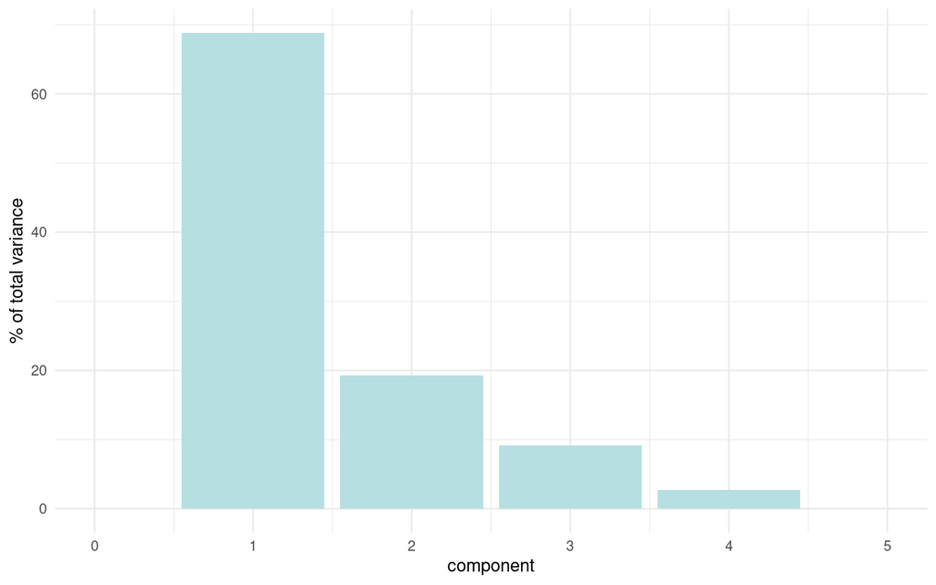

```r
penguin_recipe %>%
  tidy(id = "pca", type = "variance") %>%  # Extract variance information
  dplyr::filter(terms == "percent variance") %>%  # Filter rows for percent variance
  ggplot(aes(x = component, y = value)) +  # Create a bar plot
  geom_col(fill = "#b6dfe2") +
  xlim(c(0, 5)) +
  ylab("% of total variance")
```

- `penguin_recipe %>% tidy(id = "pca", type = "variance")` extracts information about the variance explained by each principal component. The `id = "pca"` argument specifies that the PCA results are being used, and `type = "variance"` indicates that variance-related information is being extracted.
- `dplyr::filter(terms == "percent variance")` filters the rows where the variable “`terms`” is equal to “`percent variance`,” which likely corresponds to the percentage of total variance explained by each principal component.
- `ggplot(aes(x = component, y = value))` initializes a ggplot object with the x-axis representing the principal components and the y-axis representing the percentage of total variance explained.
- `geom_col(fill = "#b6dfe2")` adds bars to the plot, and `fill = "#b6dfe2"` sets the fill color of the bars to a light blue.
- `xlim(c(0, 5))` sets the x-axis limits to be between 0 and 5, which may be useful if you want to focus on the first few principal components.
- `ylab("% of total variance")` adds a label to the y-axis indicating that it represents the percentage of total variance.

## 3.4 Plot PCA loadings

We can plot these loadings by principal component too, following Julia Silge’s example:

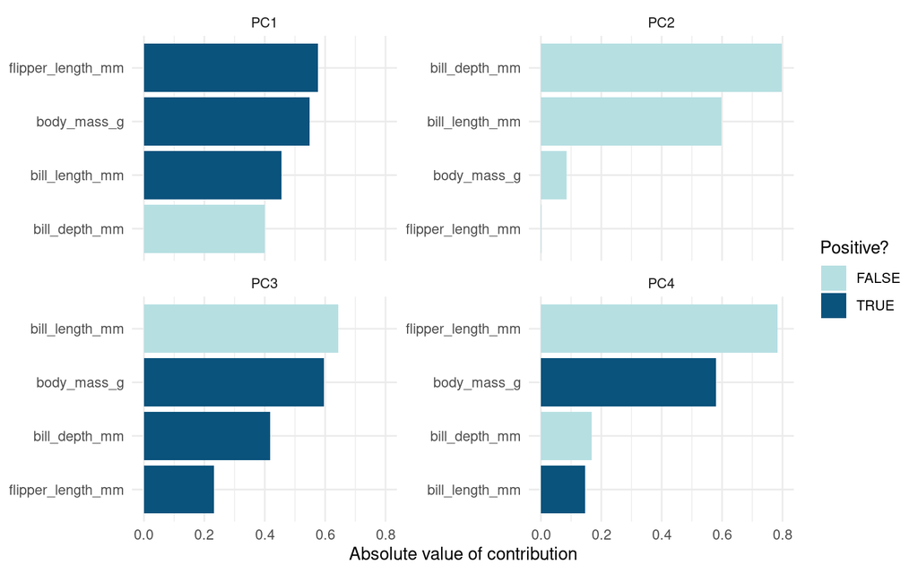

```r
library(ggplot2)
penguin_pca %>%
  mutate(terms = tidytext::reorder_within(terms,  # Modify the data
                                          abs(value),
                                          component)) %>%
  ggplot(aes(abs(value), terms, fill = value > 0)) +  # Create a grouped bar plot
  geom_col() +
  facet_wrap(~component, scales = "free_y") +  # Facet the plot by component:
  tidytext::scale_y_reordered() +  # Scale the y-axis based on reordering
  scale_fill_manual(values = c("#b6dfe2", "#0A537D")) +  # Customize fill colors
  labs(  # Set labels for axes and legend
    x = "Absolute value of contribution",
    y = NULL, fill = "Positive?"
  )
```

## 3.5 Plot PCA loadings + scores

We have the PCA loadings in `penguin_pca`. But we need them in a wide format now for plotting.

```r
# get pca loadings into wider format
pca_wider <- penguin_pca %>%
  tidyr::pivot_wider(names_from = component, id_cols = terms)
```

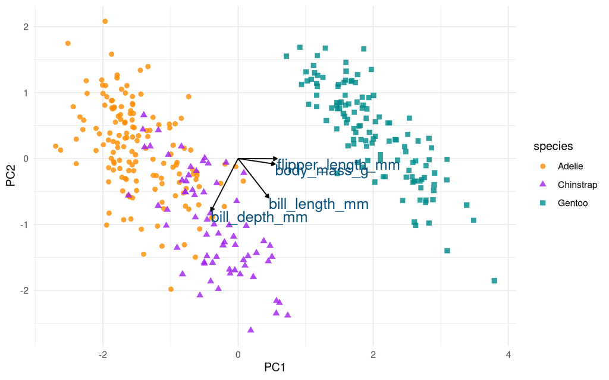

```r
# define arrow style
arrow_style <- arrow(length = unit(.05, "inches"),
                     type = "closed")

# create a scatter plote
pca_plot <-
  juice(penguin_recipe) %>%
  ggplot(aes(PC1, PC2)) +
  geom_point(aes(color = species, shape = species),
             alpha = 0.8,
             size = 2) +
  scale_colour_manual(values = c("darkorange","purple","cyan4"))

# add arrows and labels
pca_plot +
  geom_segment(data = pca_wider,
               aes(xend = PC1, yend = PC2),
               x = 0,
               y = 0,
               arrow = arrow_style) +
  geom_text(data = pca_wider,
            aes(x = PC1, y = PC2, label = terms),
            hjust = 0,
            vjust = 1,
            size = 5,
            color = '#0A537D')
```

- `arrow_style <- arrow(length = unit(.05, "inches"), type = "closed")` creates an arrow style with a length of 0.05 inches and a closed arrowhead.
- `juice(penguin_recipe) %>% ggplot(aes(PC1, PC2))` extracts the PCA scores (PC1 and PC2) from the `penguin_recipe` object and initializes a ggplot object with PC1 on the x-axis and PC2 on the y-axis.
- `geom_point(aes(color = species, shape = species), alpha = 0.8, size = 2)` adds points to the plot, colored and shaped by the “`species`” variable. The points have an alpha (transparency) of 0.8 and a size of 2.
- `scale_colour_manual(values = c("darkorange","purple","cyan4"))` manually sets the color values for the different species.
- `geom_segment` is used to add arrows to the plot. Arrows connect the origin (0, 0) to the coordinates specified by `PC1` and `PC2` from the `pca_wider` data frame.
- `geom_text` is used to add labels to the plot. Labels are placed at the coordinates specified by `PC1` and `PC2` from the `pca_wider` data frame, and the labels themselves come from the `terms` column.
- `hjust = 0` and `vjust = 1` control the horizontal and vertical justification of the text labels.
- `size = 5` sets the size of the text labels.
- `color = '#0A537D'` sets the color of the text labels.

In the above plot, you can see a lot!

First, if you focus on the x-axis showing us the first principal component, you can see that flipper length and body mass are very important (confirming what we saw in the above bar chart). Along this dimension, Gentoo penguins stand out clearly from the other two species. We can confirm this looking at summary statistics:

```r
penguins %>%
  group_by(species) %>%
  summarize(across(c(flipper_length_mm, body_mass_g),
                   mean,
                   na.rm = TRUE))
```

```
## # A tibble: 3 × 3
##   species   flipper_length_mm body_mass_g
##   <fct>                 <dbl>       <dbl>
## 1 Adelie                 190.       3701.
## 2 Chinstrap              196.       3733.
## 3 Gentoo                 217.       5076.
```

- `summarize` is used to calculate summary statistics for each group.
- `across(c(flipper_length_mm, body_mass_g), mean, na.rm = TRUE)` applies the `mean` function to specific columns (`flipper_length_mm` and `body_mass_g`) across all columns specified in `across`. The `na.rm = TRUE` argument ensures that missing values are ignored when calculating the mean.
- The result is a summary data frame with one row for each species and two columns: the mean `flipper_length_mm` and the mean `body_mass_g` for each species.

We can see this with a simple scatterplot:

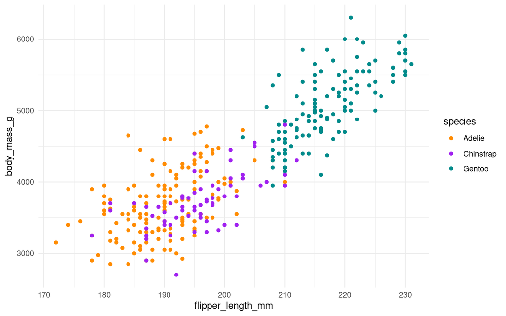

```r
ggplot(penguins, aes(x = flipper_length_mm, y = body_mass_g, colour = species)) +
  geom_point() +
  scale_colour_manual(values = c("darkorange","purple","cyan4"))
```

If you now focus more on the y-axis showing us the second principal component, you can see that our two bill size variables, `bill_length_mm` and `bill_depth_mm`, are very important (again, confirming what we saw in the above bar chart).

Let’s do the same thing for principal component 2 and 3.

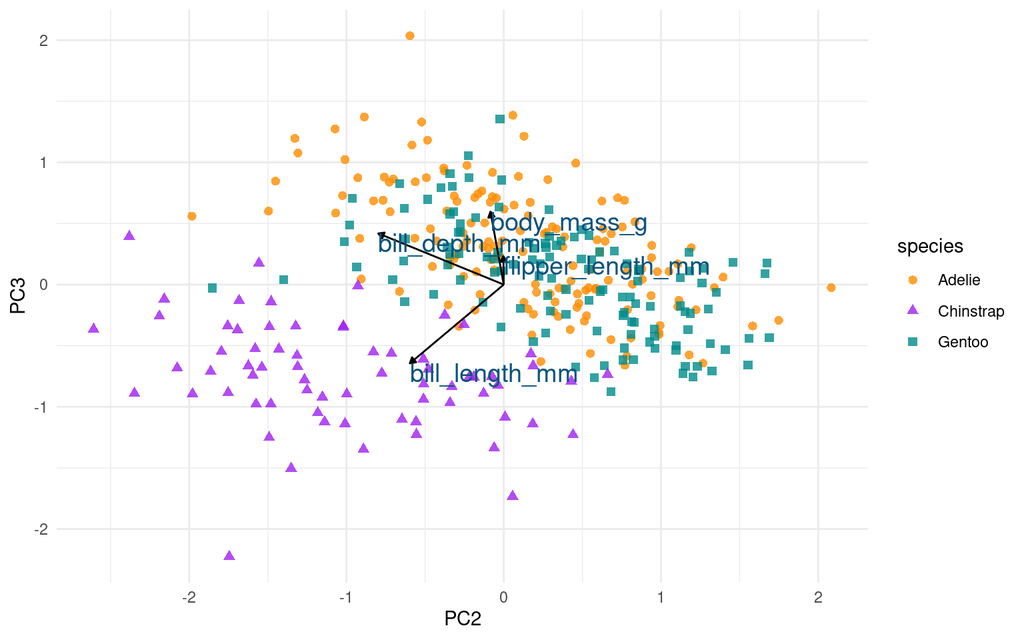

```r
pca_plot %+%
  aes(PC2, PC3) +
  geom_segment(data = pca_wider,
               aes(xend = PC2, yend = PC3),
               x = 0,
               y = 0,
               arrow = arrow_style) +
  geom_text(data = pca_wider,
            aes(x = PC2, y = PC3, label = terms),
            hjust = 0,
            vjust = 1,
            size = 5,
            color = '#0A537D')
```

We see again that PC2 seems most associated with our bill size variables, `bill_length_mm` and `bill_depth_mm`. But now we can see more clearly that this dimension seems to separate Chinstrap penguins from the other two species. We can confirm this by glancing at summary statistics again by species:

```r
penguins %>%
  group_by(species) %>%
  summarize(across(c(bill_depth_mm, bill_length_mm),
                   mean,
                   na.rm = TRUE))
```

```
## # A tibble: 3 × 3
##   species   bill_depth_mm bill_length_mm
##   <fct>             <dbl>          <dbl>
## 1 Adelie             18.3           38.8
## 2 Chinstrap          18.4           48.8
## 3 Gentoo             15.0           47.5
```

We can see this with a simple scatterplot too:

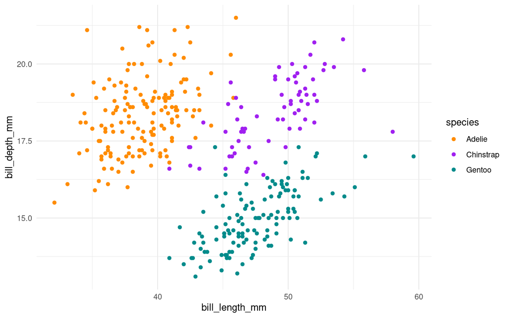

```r
ggplot(penguins, aes(x = bill_length_mm, y = bill_depth_mm, colour = species)) +
  geom_point() +
  scale_colour_manual(values = c("darkorange","purple","cyan4"))
```

This is actually a pretty neat scatterplot—it highlights a perfect example of why you’d need the combination of two variables to differentiate between these three species. Comparing distributions for any single variable only differentiates one species from the other two!

# 4. UMAP with penguins

```r
library(embed)
# Create a recipe for preprocessing and PCA transformation
penguin_recipe <-
  recipe(~., data = penguins) %>%  # Create a recipe
  update_role(species, island, sex, year, new_role = "id") %>%  # Update roles
  step_naomit(all_predictors()) %>%  # Handle missing values
  step_normalize(all_predictors()) %>%  # Normalize predictors
  step_umap(all_predictors(), id = "umap") %>%  # Apply PCA
  prep()  # Prepare the recipe
# Apply the recipe and extract the PCA results
penguin_umap <-
  penguin_recipe %>%
  juice()
# Display the PCA results
penguin_umap
```

```
## # A tibble: 342 × 6
##    species island    sex     year UMAP1  UMAP2
##    <fct>   <fct>     <fct>  <int> <dbl>  <dbl>
##  1 Adelie  Torgersen male    2007 -7.36  0.585
##  2 Adelie  Torgersen female  2007 -7.27  1.59
##  3 Adelie  Torgersen female  2007 -6.85  2.08
##  4 Adelie  Torgersen female  2007 -5.88  0.352
##  5 Adelie  Torgersen male    2007 -5.76 -0.725
##  6 Adelie  Torgersen female  2007 -7.29  1.22
##  7 Adelie  Torgersen male    2007 -6.90 -1.46
##  8 Adelie  Torgersen <NA>    2007 -5.60  1.43
##  9 Adelie  Torgersen <NA>    2007 -6.31 -1.59
## 10 Adelie  Torgersen <NA>    2007 -6.13  2.42
## # ℹ 332 more rows
```

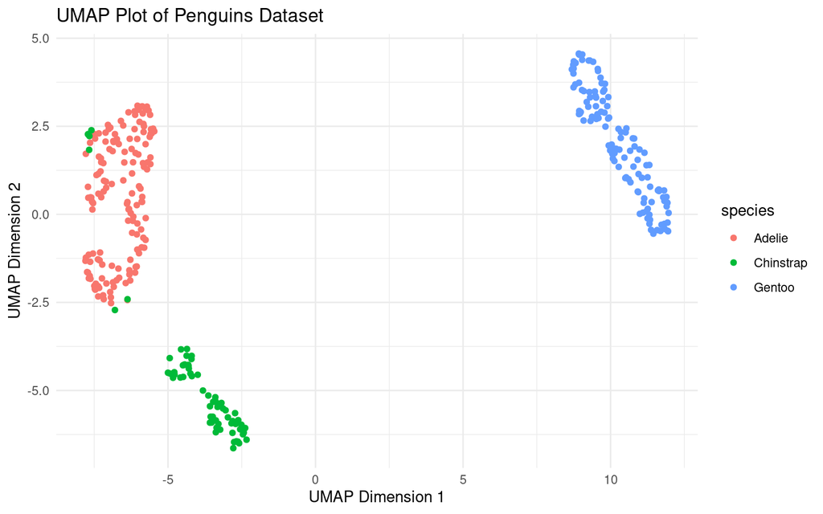

```r
library(ggplot2)
ggplot(penguin_umap, aes(x = UMAP1, y = UMAP2)) +
  geom_point(aes(color = species)) +
  labs(title = "UMAP Plot of Penguins Dataset", x = "UMAP Dimension 1", y = "UMAP Dimension 2") +
  theme_minimal()
```